# Applications of Particle Filtering and

## Example without Re-sampling

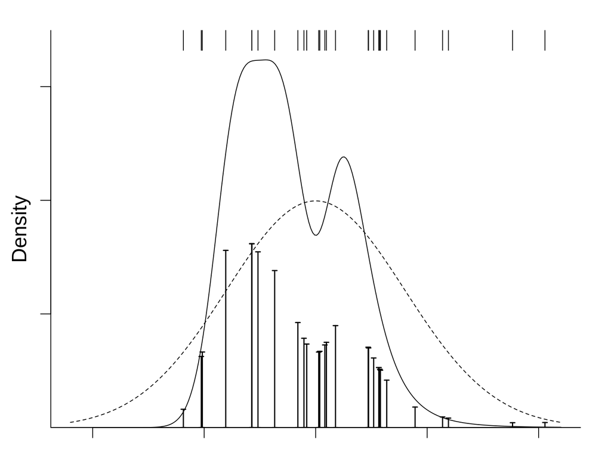

## Example with Re-sampling

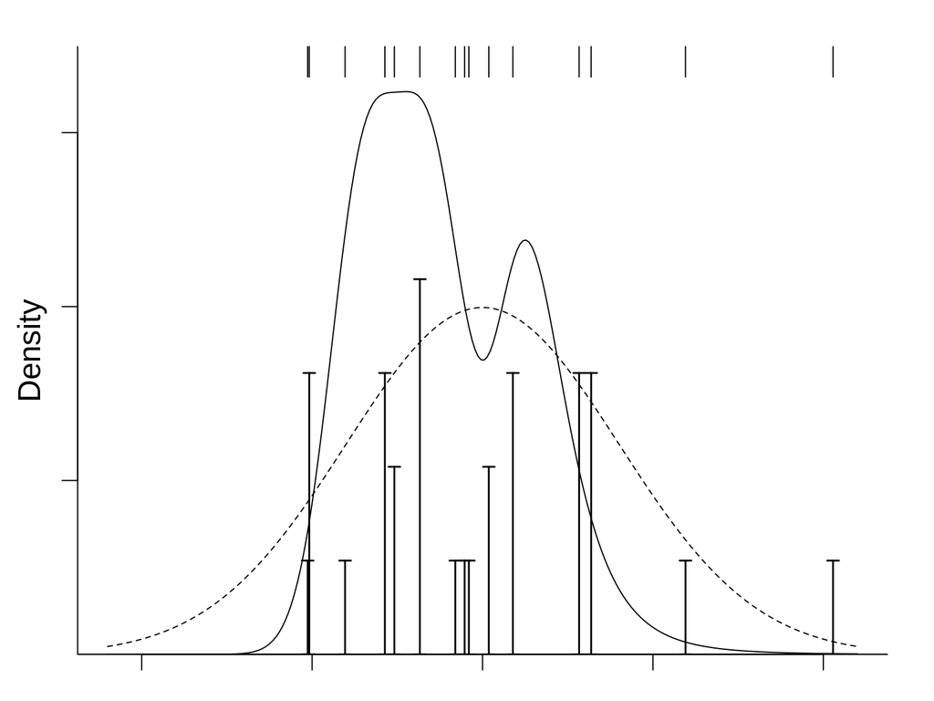

## Example with More Samples

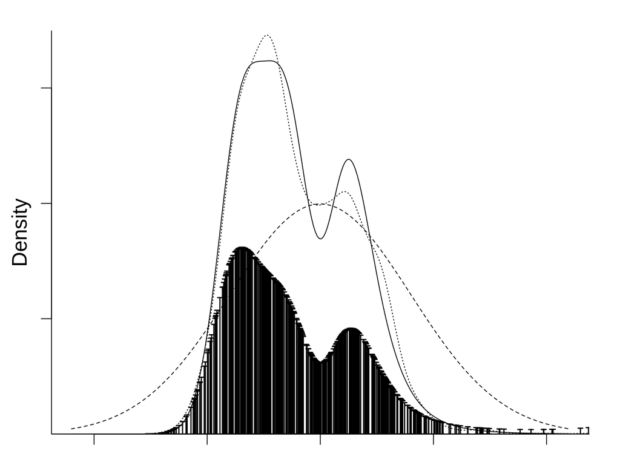

## Points

$q$ needs to be fast to sample from and evaluate.

$q$ needs to be a good approximation of $h$.

Many variance reduction methods

E.g., antithetic variables as used in the `mssm` package. E.g., see Durbin and Koopman (1997).

Often in-accurate in higher dimensions.

# Particle Filtering

## End Goal

Cover smoothers in the `dynamichazard` package.

$$\begin{align*}
Q\Cond{\vec\beta, \mat\Sigma}
{\widehat{\vec\beta}, \widehat{\mat\Sigma}} \hspace{-30pt}& \\
&=\expec_{(\widehat{\vec\beta}, \widehat{\mat\Sigma})}
\Big(
\log \mu(\vec U_1)
+ \log g(\vec T_1, \vec D_1; \mat X_1, \mat Z_1, \vec U_1) \\
&\hspace{50pt}
+\sum_{k = 2}^{\bar t}
\log g(\vec T_k, \vec D_k; \mat X_k, \mat Z_k, \vec U_k) \\
&\hspace{70pt}+
\log\phi(\vec U_k; \mat F\vec U_{k-1}, \mat\Sigma)
\,\Big|\, \vec t_{1:\bar t}, \vec d_{1:\bar t}\Big)
\end{align*}$$

Need $p\Cond{\vec U_{k-1:k}}{\vec t_{1:\bar t}, \vec d_{1:\bar t}}$.

## Notation

(Forward) particle filter $(\part{\rR{\vec u}}{s}_{1:k}, \part{\rR{W}}{s}_{k})_{s=1,\dots,N}$.

Backward particle filter $(\part{\lR{\vec u}}{s}_k, \part{\lR{W}}{s}_k)_{s=1,\dots,N}$.

Smoothed particles $(\part{\bR{\vec u}}{s}_k, \part{\bR{W}}{s}_k)_{s=1,\dots,N}$.

## Particle Filter

Have some estimate of $p\Cond{\vec u_{1:k-1}}{\vec t_{1:k-1}, \vec d_{1:k-1}}$.

Use
$$\begin{align*}
p\Cond{\vec u_{1:k}}{\vec t_{1:k}, \vec d_{1:k}} \hspace{-50pt}&\\
&=
p\Cond{\vec u_{1:k-1}}{\vec t_{1:k-1}, \vec d_{1:k-1}}
\frac{g_k\Cond{\vec t_k, \vec d_k}{\vec u_k}
h\Cond{\vec u_k}{\vec u_{k - 1}}}
{p\Cond{\vec t_k, \vec d_k}{\vec t_{1:k-1}, \vec d_{1:k-1}}} \\
&\approx \sum_{s = 1}^N \part{\rR{W}}{s}_{k-1}
\delta_{\part{\rR{\vec u}}{s}_{1:k-1}}(\vec u_{1:k-1})
\frac{g_k\Cond{\vec t_k, \vec d_k}{\vec u_k}
h\Cond{\vec u_k}{\part{\rR{\vec u}}{s}_{1:k-1}}}
{p\Cond{\vec t_k, \vec d_k}{\vec t_{1:k-1}, \vec d_{1:k-1}}}
\end{align*}$$

where $\delta$ is the Dirac delta function, $g_k\Cond{\vec t_k, \vec d_k}{\vec u_k} = g(\vec t_k, \vec d_k;\mat X_k, \mat Z_k, \vec u_k)$, and $h\Cond{\vec u_k}{\vec u_{1:k - 1}} = \phi(\vec u_k; \mat F\vec u_{k-1}, \mat\Sigma)$.

## Auxiliary Particle Filter

Some weights, $\part{\rR{W}}{s}_k$, quickly get all the mass.

Weight degeneracy.

Advantageous to re-sample with weights
$$\part{\rR{\beta}}{s}_k \apxprop
p\Cond{\vec t_k, \vec d_k}{\part{\rR{\vec u}}{s}_{1:k-1}}
\part{\rR{W}}{s}_{1:k-1}$$

An auxiliary particle filter (Pitt and Shephard 1999).

## Auxiliary Particle Filter Algorithm

1. Sample $j_1,\dots,j_N$ using $\{\part{\rR{\beta}}{s}_k\}_{s=1,\dots,N}$.
2. Sample new *state*
   $$\part{\rR{\vec u}}{s}_k \sim \rR{q}_k\Cond{\cdot}{
   \part{\rR{\vec u}}{j_s}_{1:k-1}, \vec t_k, \vec d_k}$$
3. Compute and normalize weights
   $$\begin{align*}
   \widetilde W_s &=
   \frac {\part{\rR{W}}{j_s}_{k-1}}{\part{\rR{\beta}}{j_s}_k}
   \frac{g_k\Cond{\vec t_k, \vec d_k}{\part{\rR{\vec u}}{s}_k}
   h\Cond{\part{\rR{\vec u}}{s}_k}{\part{\rR{\vec u}}{j_s}_{1:k-1}}}
   {\rR{q}_k\Cond{\part{\rR{\vec u}}{s}_k}{
   \part{\rR{\vec u}}{j_s}_{1:k-1}, \vec t_k, \vec d_k}} \\
   \part{\rR{W}}{s}_k &= \widetilde W_s / \sum_{i = 1}^N \widetilde W_i
   \end{align*}$$

## Implementation Details

Both sampling and computation of weights require $N$ similar and independent computations.

Easily done in parallel

as in the `dynamichazard` and `mssm` using the C++ `thread` library.

Largest computational cost

as $g_k$ is relatively expensive to evaluate when $\vec t_k$ and $\vec d_k$ has many elements.

# Particle Smoothing

## Issue with Particle Filter

Can use $(\part{\rR{\vec u}}{s}_{1:\bar t}, \part{\rR{w}}{s}_{\bar t})$ for $s = 1, \dots, N$.

Often few unique values of $\vec u_k$ with small $k$

due to weight degeneracy.

## Smoother from Briers, Doucet, and Maskell (2009)

Use the identity

$$\begin{align*}
p\Cond{\vec u_k}{\vec t_{1:\bar t}, \vec d_{1:\bar t}}
&= \frac
{p\Cond{\vec u_k}{\vec t_{1:k -1}, \vec d_{1:k -1}}
p\Cond{\vec t_{k:\bar t}, \vec d_{k:\bar t}}{\vec u_k}}
{p\Cond{\vec t_{k:\bar t}, \vec d_{k:\bar t}}
{\vec t_{1:k-1}, \vec d_{1:k-1}}} \\
&\propto\int h\Cond{\vec u_k}{\vec u_{k - 1}}
p\Cond{\vec u_{k-1}}{\vec t_{1:k-1}, \vec d_{1:k-1}}\der\vec u_{k-1}\\
&\hspace{40pt}
\cdot p\Cond{\vec t_{k:\bar t}, \vec d_{k:\bar t}}{\vec u_k}
\end{align*}$$

Have an approximation of $p\Cond{\vec u_{k-1}}{\vec t_{1:k-1}, \vec d_{1:k-1}}$ but not $p\Cond{\vec t_{k:\bar t}, \vec d_{k:\bar t}}{\vec u_k}$.

## Backward Particle Filter

Run a backward particle filter to get $(\part{\lR{\vec u}}{s}_k, \part{\lR{W}}{s}_k)_{s=1,\dots,N}$ targeting an artificial $\tilde p\Cond{\vec u_k}{\vec t_{k:\bar t}, \vec d_{k:\bar t}}$.

Has the property that
$$p\Cond{\vec t_{k:\bar t}, \vec d_{k:\bar t}}{\vec u_k} \propto
\frac{\tilde p\Cond{\vec u_k}{\vec t_{k:\bar t}, \vec d_{k:\bar t}}}
{\gamma_k\left(\vec u_k\right)}
\approx \sum_{s = 1}^N \frac
{\part{\lR{W}}{s}_k}{\gamma_k\left(\part{\lR{\vec u}}{s}_k\right)}
\delta_{\part{\lR{\vec u}}{s}_k}(\vec u_k)$$

for a prespecified density function $\gamma_k$.

## Comments

Smoothed weights are given by

$$\begin{align*}
\part{\bR{W}}{s}_k \propto \sum_{i = 1}^N
h\Cond{\part{\lR{\vec u}}{s}_k}{\part{\rR{\vec u}}{i}_{k -1}}
\part{\rR{W}}{i}_{k -1}\frac
{\part{\lR{W}}{s}_k}
{\gamma_k\left({\part{\lR{\vec u}}{s}_k}\right)}
\end{align*}$$

We get $2N$ evaluations of $g$.

$\bigO{N^2}$

but can be reduced an average case of $\bigO{N\log N}$ with the dual k-d tree method as implemented in the `mssm` package.

## Smoother from Fearnhead, Wyncoll, and Tawn (2010)

$$\begin{align*}
p\Cond{\vec u_k}{\vec t_{1:\bar t}, \vec d_{1:\bar t}}\hspace{-50pt}& \\
&= \frac
{p\Cond{\vec u_k}{\vec t_{1:k -1}, \vec d_{1:k -1}}
g_k\Cond{\vec t_k, \vec d_k}{\vec u_k}
p\Cond{\vec t_{k + 1:\bar t}, \vec d_{k + 1:\bar t}}{\vec u_k}}
{p\Cond{\vec t_{k:\bar t}, \vec d_{k:\bar t}}
{\vec t_{1:k-1}, \vec d_{1:k-1}}} \\
&\propto\int h(\vec u_k, \vec u_{k - 1})
p\Cond{\vec u_{k-1}}{\vec t_{1:k-1}, \vec d_{1:k-1}}\der\vec u_{k-1}\\
&\hspace{20pt}
\cdot g_k\Cond{\vec t_k, \vec d_k}{\vec u_k}
\int p\Cond{\vec t_{k + 1:\bar t}, \vec d_{k + 1:\bar t}}{\vec u_{k + 1}} \\
&\hspace{100pt}
\cdot h\Cond{\vec u_{k+1}}{\vec u_k}\der \vec u_{k + 1}
\end{align*}$$

## Algorithm

1. Sample $(i_s, j_s)_{s = 1,\dots N}$ using $\{\part{\rR{\beta}}{i}_k\}_{i=1,\dots,N}$ and $\{\part{\lR{\beta}}{j}_k\}_{j=1,\dots,N}$.
2. Sample
   $$\part{\bR{\vec u}}{s}_k \sim
   \bR q_k\Cond{\cdot}{\part{\rR{\vec u}}{i_s}_{k-1},
   \part{\lR{\vec u}}{j_s}_{k+1}, \vec t_k, \vec d_k}$$

## Algorithm

3. Compute and normalize weights
   $$\begin{align*}
   \widetilde W_s &= \frac
   {h\Cond{\part{\bR{\vec u}}{s}_k}{\part{\rR{\vec u}}{i_s}_{k - 1}}
   g_k\Cond{\vec t_k, \vec d_k}{\part{\bR{\vec u}}{s}_k}
   h\Cond{\part{\lR{\vec u}}{j_s}_{k + 1}}{\part{\bR{\vec u}}{s}_k}}
   {\bR q_k\Cond{\part{\bR{\vec u}}{s}_k}{\part{\rR{\vec u}}{i_s}_{k-1},
   \part{\lR{\vec u}}{j_s}_{k+1}, \vec t_k, \vec d_k}} \\
   &\hspace{20pt}
   \cdot \frac
   {\part{\lR{W}}{j_s}_{k+1}\part{\rR{W}}{i_s}_{k-1}}
   {\gamma_{k + 1}\left(\part{\lR{\vec u}}{j_s}_{k+1}\right)
   \part{\lR{\beta}}{j_s}_{k+1}
   \part{\rR{\beta}}{i_s}_{k-1}} \\
   \part{\bR{W}}{s}_k &= \widetilde W_s / \sum_{o = 1}^N \widetilde W_o
   \end{align*}$$

## Comments

We get $3N$ evaluations of $g$.

$\bigO{N}$.

Can be generalized to handle singular components.

# Implementation

## Dynamichazard

Both smoothers.

All in C++ with parallel computation using the C++ `thread` library.

Computation in M-step is done in parallel in a memory efficient manner

using QR decompositions as in the `bam` function in `mgcv` package.

# Gradient and Hessian Approximations

## Motivation

Cover methods in `mssm` package.

Direct maximization

using an approximation of $L'(\vec\beta, \mat \Sigma)$.

Estimate of $L''(\vec\beta, \mat \Sigma)$ at the maximum.

## Method

Can use the forward particle filter to approximate

$$\begin{align*}
L'(\vec\theta) &= \int
\nabla_{\vec\theta}\log f(\vec T_{1:\bar t}, \vec D_{1:\bar t},
\vec U_{1:\bar t}; \vec\theta) \\
&\hspace{80pt}
\cdot p\Cond{\vec u_{1:\bar t}}{\vec t_{1:\bar t}, \vec d_{1:\bar t}}
\der\vec u_{1:\bar t}
\end{align*}$$

where $\vec\theta = (\vec\beta, \mat\Sigma)$.

And a similar expression $L''(\vec\beta, \mat \Sigma)$ using Louis’ identity (Louis 1982).

In-accurate due to weight degeneracy.

## Alternative

Poyiadjis, Doucet, and Singh (2011) show a recursive method with better properties.

Requires evaluation of
$$\sum_{i = 1}^N \frac{\part{\rR{W}}{i}_{k - 1}
h\Cond{\part{\rR{\vec u}}{s}_k}{\part{\rR{\vec u}}{i}_{k - 1}}}
{\sum_{j = 1}^N\part{\rR{W}}{j}_{k - 1}
h\Cond{\part{\rR{\vec u}}{s}_k}{\part{\rR{\vec u}}{j}_{k - 1}}}
\psi\left(\part{\rR{\vec u}}{s}_k, \part{\rR{\vec u}}{i}_{k - 1}\right)$$

for some function $\psi$ as the smoother suggested by Briers, Doucet, and Maskell (2009).

## Dual k-d Tree

Can use that for some $s\in\mathcal{S}$, $i\in\mathcal{I}$, and constant $C$

$$h\Cond{\part{\rR{\vec u}}{s}_k}{\part{\rR{\vec u}}{i}_{k - 1}} \approx C$$

when $\part{\rR{\vec u}}{s}_k$ are similar for $s\in\mathcal{S}$ and similarly for $i\in\mathcal{I}$.

Form two k-d trees and make an approximation as in Klaas et al. (2006).

## Fast Approximation

```r
##          method
## N         Dual-tree      Naive
##   12288    0.039704  0.7137595
##   24576    0.062140  2.6771194
##   49152    0.115722 10.9796716
##   98304    0.227879         NA
##   196608   0.450209         NA
##   393216   0.913649         NA
##   786432   1.844256         NA
##   1572864  4.057902         NA
```

Units are seconds.

## mssm Package

Supports a wider range of models (not limited to survival models).

All the computation is in C++ with parallel computation using the C++ `thread` library.

Can be used for clustered data

as the method can be used to get gradients for multiple different groups.

“More work” required by the user.

# Final Comments

## Proposal Distribution

The proposal distribution is important.

Bootstrap filter (Gordon, Salmond, and Smith 1993) using $h$ is implemented, along with various mode approximations

using either a multivariate normal distribution or multivariate $t$-distribution.

## Summary

Mixed models is an alternative when one is interested in extrapolation.

Particle based methods can provide an efficient means of working with the presented mixed models.

There are complications with particle based methods and potential solutions.

A broad overview of the methods in `dynamichazard` and `mssm` package.

# Thank You!

The presentation is at rpubs.com/boennecd/PFnSiML.

The markdown is at github.com/boennecd/Talks.

The `dynamichazard` package is at github.com/boennecd/dynamichazard.

The `mssm` package is at github.com/boennecd/mssm.

References are on the next slide.

# References

Briers, Mark, Arnaud Doucet, and Simon Maskell. 2009. “Smoothing Algorithms for State–Space Models.” *Annals of the Institute of Statistical Mathematics* 62 (1): 61. doi:10.1007/s10463-009-0236-2.

Dempster, A. P., N. M. Laird, and D. B. Rubin. 1977. “Maximum Likelihood from Incomplete Data via the Em Algorithm.” *Journal of the Royal Statistical Society. Series B (Methodological)* 39 (1). [Royal Statistical Society, Wiley]: 1–38. http://www.jstor.org/stable/2984875.

Durbin, J., and S. J. Koopman. 1997. “Monte Carlo Maximum Likelihood Estimation for Non-Gaussian State Space Models.” *Biometrika* 84 (3). [Oxford University Press, Biometrika Trust]: 669–84. http://www.jstor.org/stable/2337587.

Fearnhead, Paul, David Wyncoll, and Jonathan Tawn. 2010. “A Sequential Smoothing Algorithm with Linear Computational Cost.” *Biometrika* 97 (2). [Oxford University Press, Biometrika Trust]: 447–64. http://www.jstor.org/stable/25734097.

Gordon, N. J., D. J. Salmond, and A. F. M. Smith. 1993. “Novel Approach to Nonlinear/Non-Gaussian Bayesian State Estimation.” *IEE Proceedings F - Radar and Signal Processing* 140 (2): 107–13. doi:10.1049/ip-f-2.1993.0015.

Klaas, Mike, Mark Briers, Nando de Freitas, Arnaud Doucet, Simon Maskell, and Dustin Lang. 2006. “Fast Particle Smoothing: If I Had a Million Particles.” In *Proceedings of the 23rd International Conference on Machine Learning*, 481–88. ICML ’06. New York, NY, USA: ACM. doi:10.1145/1143844.1143905.

Louis, Thomas A. 1982. “Finding the Observed Information Matrix When Using the Em Algorithm.” *Journal of the Royal Statistical Society. Series B (Methodological)* 44 (2). [Royal Statistical Society, Wiley]: 226–33. http://www.jstor.org/stable/2345828.

Pitt, Michael K., and Neil Shephard. 1999. “Filtering via Simulation: Auxiliary Particle Filters.” *Journal of the American Statistical Association* 94 (446). [American Statistical Association, Taylor & Francis, Ltd.]: 590–99. http://www.jstor.org/stable/2670179.

Poyiadjis, George, Arnaud Doucet, and Sumeetpal S. Singh. 2011. “Particle Approximations of the Score and Observed Information Matrix in State Space Models with Application to Parameter Estimation.” *Biometrika* 98 (1). Biometrika Trust: 65–80. http://www.jstor.org/stable/29777165.

Royston, Patrick, and Mahesh K. B. Parmar. 2002. “Flexible Parametric Proportional-Hazards and Proportional-Odds Models for Censored Survival Data, with Application to Prognostic Modelling and Estimation of Treatment Effects.” *Statistics in Medicine* 21 (15): 2175–97. doi:10.1002/sim.1203.